# Reproducing analyses from the Cochrane DTA handbook in MetaBayesDTA v2.0

## 2.3 Analyse the data

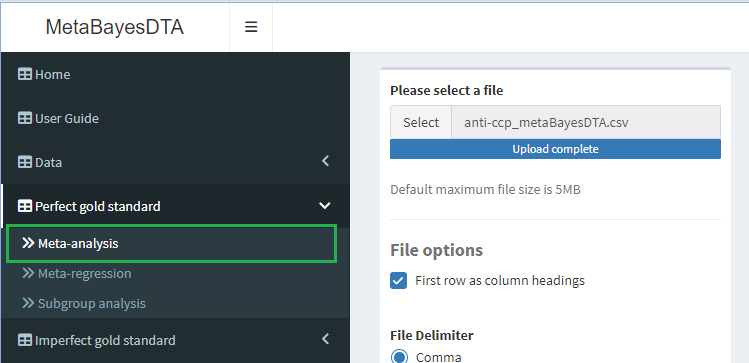

On the **Priors** tab there are two drop-down menus that contain options for sampling in Stan and prior distributions. They can both be left at their default values in this example. Navigate to the **Run model** tab.

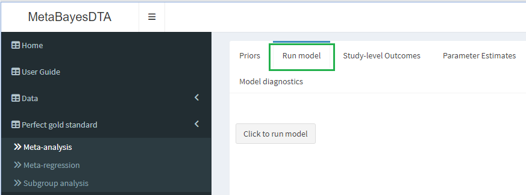

Run the model.

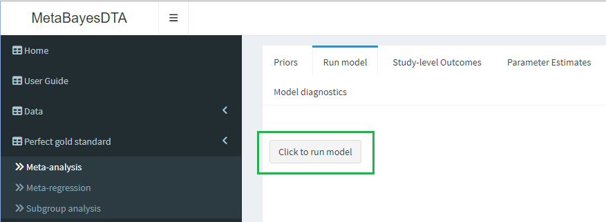

A text box will pop up. Click **OK** to close it.

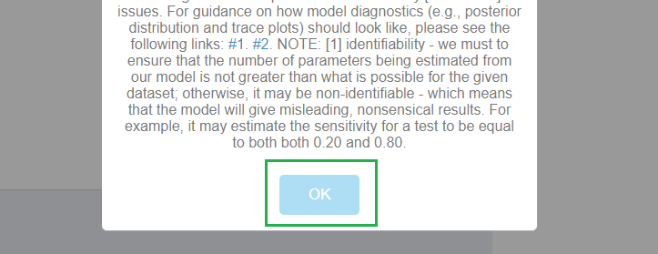

It will take some time for the model to run, and may appear that nothing is happening. Be patient! When the analysis has finished running, the SROC plot will appear on the right of the screen.

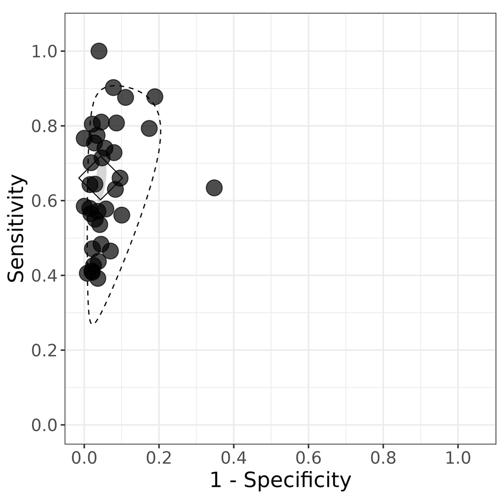

## 2.4 Compare the parameters

Navigate to the **Parameter Estimates** tab.

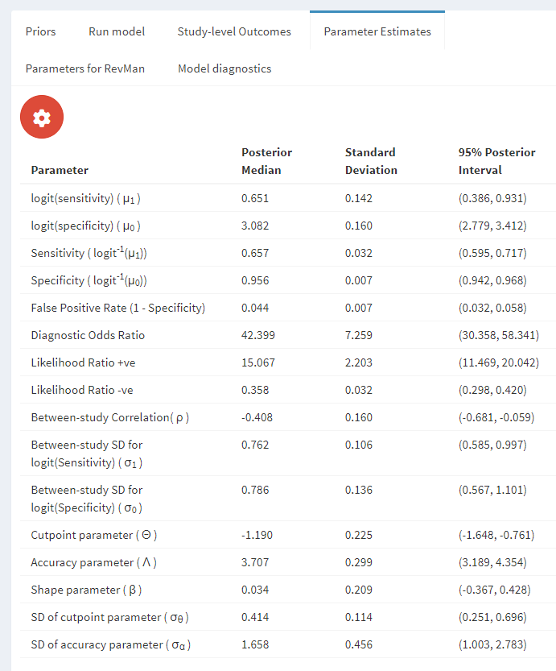

The table below is from chapter 9, page 16, of the handbook, and contains the parameter estimates and their standard errors from the frequentist Bivariate model.

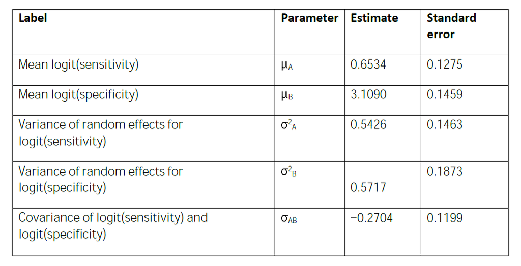

Figure 2.1: Parameter estimates from the frequentist bivariate model

Next are the estimated means and standard deviations of the parameters, together with quantiles, from the Bayesian model, found in chapter 10, page 17 of the handbook.

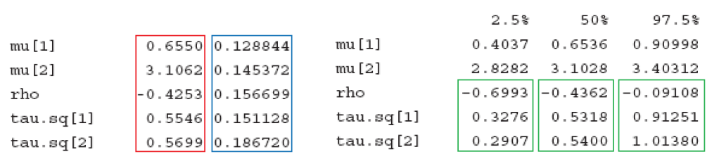

Figure 2.2: Parameter estimates from the Bayesian bivariate model

The three sources use different notation for the parameters. The table below shows which parameters are which.

| Parameters |  |  |  |  |  |
| --- | --- | --- | --- | --- | --- |
| Cochrane frequentist | $\mu_A$ | $\mu_B$ | $\sigma_A^2$ | $\sigma_B^2$ | $\sigma_{AB} / \sigma_A \sigma_B$ |
| Cochrane Bayesian | mu[1] | mu[2] | tau.sq[1] | tau.sq[2] | rho |
| MetaBayesDTA | $\mu_1$ | $\mu_0$ | $\sigma_1^2$ | $\sigma_0^2$ | $\rho$ |

MetaBayesDTA does not currently produce estimates of all of the parameters in the Cochrane handbook. However, all the output in the handbook can be estimated from MetaBayesDTA output. This is done for each parameter in the following subsections, with justification for the calculations provided in the appendix.

Each subsection has a summary table in which the parameter estimates and standard deviations are displayed. For the frequentist models these are parameter estimates and their standard errors. For the Bayesian models they are the median and standard deviation of the posterior distributions. In addition, there are 95% posterior intervals for the Bayesian models.

Since the estimation methods used for the Bayesian analysis are based on simulations, values can vary slightly with each analysis. The variability can be reduced by increasing the number of iterations.

### 2.4.1 Mean logit sensitivity ($\mu_A$)

|  | Estimate | Standard deviation | Lower 95% limit | Upper 95% limit |
| --- | --- | --- | --- | --- |
| Cochrane frequentist | 0.6534 | 0.1275 | NA | NA |
| Cochrane Bayesian | 0.6536 | 0.1288 | 0.4037 | 0.910 |
| MetaBayesDTA | 0.6510 | 0.1420 | 0.3860 | 0.931 |

### 2.4.2 Mean logit specificity ($\mu_B$)

|  | Estimate | Standard deviation | Lower 95% limit | Upper 95% limit |
| --- | --- | --- | --- | --- |
| Cochrane frequentist | 3.1090 | 0.1459 | NA | NA |
| Cochrane Bayesian | 3.1028 | 0.1454 | 2.8282 | 3.4031 |
| MetaBayesDTA | 3.0820 | 0.1600 | 2.7790 | 3.4120 |

### 2.4.3 Variance of random effects for logit sensitivity ($\sigma_A^2$)

|  | Estimate | Standard deviation | Lower 95% limit | Upper 95% limit |
| --- | --- | --- | --- | --- |
| Cochrane frequentist | 0.5426 | 0.1463 | NA | NA |
| Cochrane Bayesian | 0.5318 | 0.1511 | 0.3276 | 0.9125 |
| MetaBayesDTA | 0.5806 | 0.1369 | 0.3422 | 0.994 |

In MetaBayesDTA, between study SD for logit(sensitivity) = 0.762. This is the square root of the variance, so the variance estimate is $0.762^2 = 0.5806$. The posterior interval can be similarly transformed into an interval for the variance:

$$(0.585 ^2, 0.997 ^2) = (0.342, 0.994).$$

The standard deviation of $\sigma_A^2$ can be estimated by

$$SD(\sigma_A^2) = \sqrt{2} \times 0.5806 / \sqrt{36} = 0.1369$$

where 36 is the number of trials minus 1.

### 2.4.4 Variance of random effects for logit specificity ($\sigma_B^2$)

|  | Estimate | Standard deviation | Lower 95% limit | Upper 95% limit |
| --- | --- | --- | --- | --- |
| Cochrane frequentist | 0.5717 | 0.1873 | NA | NA |
| Cochrane Bayesian | 0.54 | 0.1867 | 0.2907 | 1.0138 |
| MetaBayesDTA | 0.6178 | 0.1456 | 0.3215 | 1.212 |

In MetaBayesDTA, between study SD for logit(specificity) = 0.786. This is the square root of the variance, so the variance estimate is $0.786^2 = 0.6178$. The posterior interval can be similarly transformed into an interval for the variance:

$$(0.567 ^2, 1.101 ^2) = (0.321, 1.212).$$

The standard deviation of $\sigma_B^2$ can be estimated by

$$SD(\sigma_B^2) = \sqrt{2} \times 0.6178 / \sqrt{36} = 0.1456$$

where 36 is the number of trials minus 1.

### 2.4.5 Correlation of logit sensitivity and logit specificity ($\rho$)

|  | Estimate | Standard deviation | Lower 95% limit | Upper 95% limit |
| --- | --- | --- | --- | --- |
| Cochrane frequentist | -0.4855 | 0.1274 | NA | NA |
| Cochrane Bayesian | -0.4362 | 0.1567 | -0.6993 | -0.0911 |
| MetaBayesDTA | -0.408 | 0.16 | -0.6810 | -0.0590 |

The frequentist model provides an estimate of the covariance $\sigma_{AB}$ rather than the correlation $\rho$. The covariance estimate is $-0.2704$. This can be converted into a correlation by dividing by the product of the standard deviations of logit sensitivity and logit specificity:

$$-0.2704 / (\sqrt{0.5426} \times \sqrt{0.5717}) = -0.4855.$$

Its standard error can be estimated as

$$(1 - (-0.4855)^2) / \sqrt{36} = 0.127$$

where 36 is the number of trials minus 1.

# 3 Rutter and Gatsonis HSROC model, 9.4.4 Example 2: Rheumatoid factor as a marker for rheumatoid arthritis

MetaBayesDTA does not directly fit the HSROC model. However, when there are no covariates the HSROC model is equivalent to the bivariate model, and the parameter estimates from each model can be derived from the other. MetaBayesDTA provides parameter estimates for the HSROC model in this case by deriving them from the parameters of the bivariate model.

Since there is no practical difference for the user in fitting the HSROC model compared to the bivariate model, the instructions from the previous example can be followed. The exception is that the SROC plot does not include a curve by default, so the following are instructions on how the curve can be added.

The dataset in this example is *RF.csv*.

## 3.1 Add the SROC curve

By default the SROC plot should look like this.

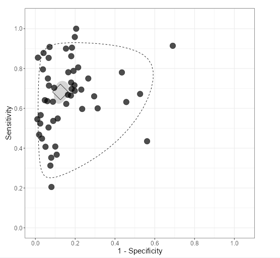

On the **sROC Plot** tab, select the settings drop-down menu.

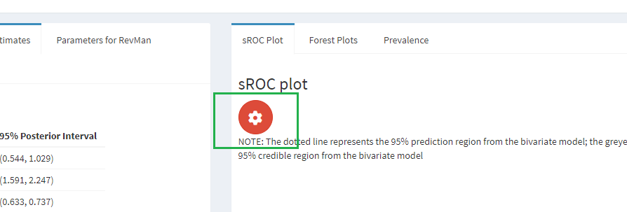

Under **Options**, tick the **sROC curve** box.

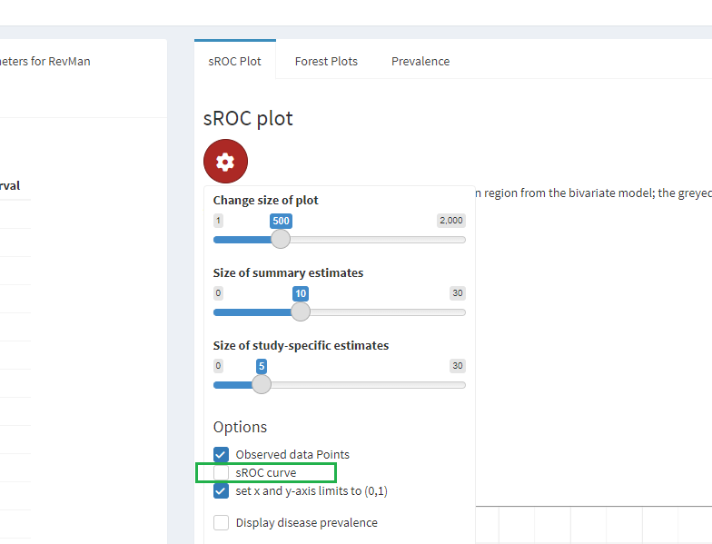

The SROC plot should now look like this.

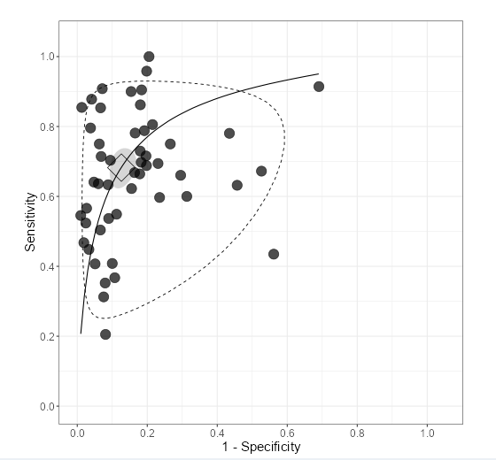

## 3.2 Compare the parameters

These are the parameter estimates from MetaBayesDTA.

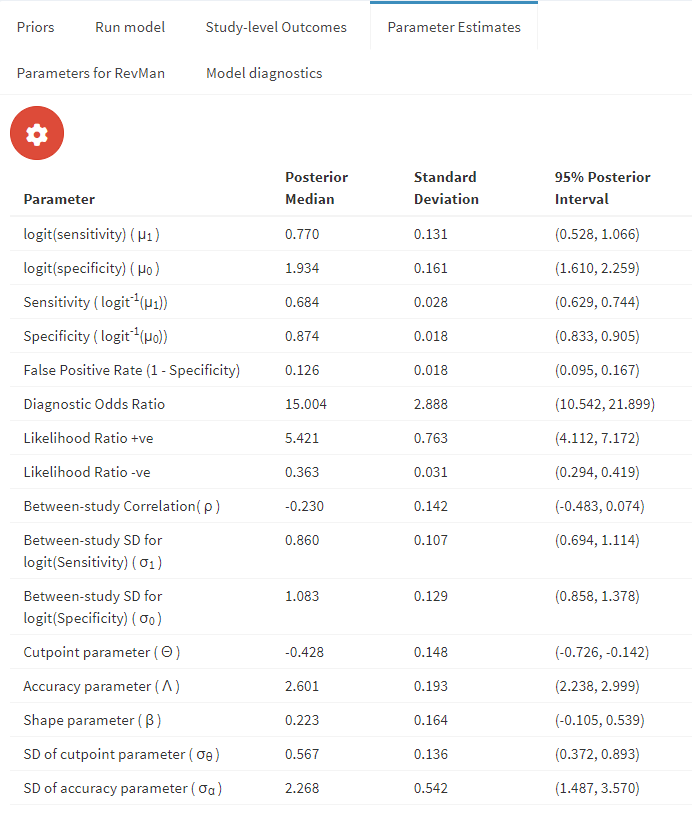

The table below is from chapter 9, page 20, of the handbook, and contains the parameter estimates and their standard errors from the frequentist HSROC model. (The parameter $\sigma_\theta$ is incorrectly written as $\sigma_\beta$).

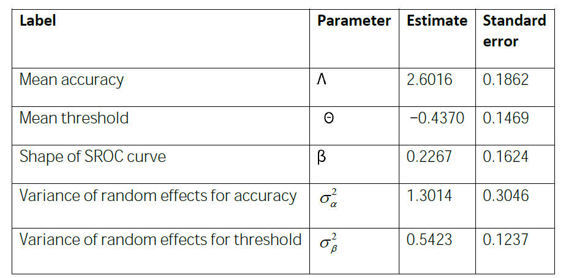

Next are the estimated means and standard deviations of the parameters, together with quantiles, from the Bayesian model, found in chapter 10, page 24 of the handbook.

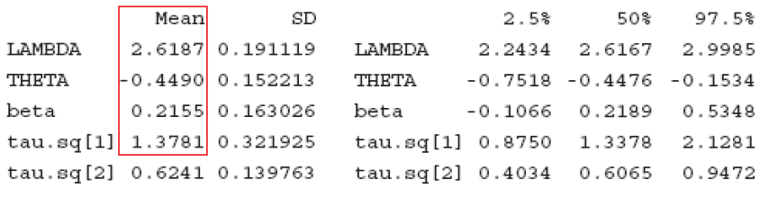

The three sources use different notation for the parameters. The table below shows which parameters are which.

| Parameters |  |  |  |  |  |
| --- | --- | --- | --- | --- | --- |
| Cochrane frequentist | $\Lambda$ | $\Theta$ | $\beta$ | $\sigma_\alpha^2$ | $\sigma_\theta^2$ |
| Cochrane Bayesian | LAMBDA | THETA | beta | tau.sq[1] | tau.sq[2] |
| MetaBayesDTA | $\Lambda$ | $\Theta$ | $\beta$ | $\sigma_\alpha^2$ | $\sigma_\theta^2$ |

# 4 Meta-regression in the bivariate model, 9.4.6.3 Example 1 continued: Investigation of heterogeneity in diagnostic performance of anti‐CCP

This is an extension of the model from section 2, using the same data set, *anti-cpp.csv*. Only the steps that are different from those in that section are shown.

## 4.1 Format the dataset

The name of a covariate should end with *.cat* for categorical covariates and *.cts* for continuous covariates. The covariate in this example is **Generation**, which should be renamed to **Generation.cat**.

## 4.2 Analyse the data

There is one step different from section 2, to select **Meta-regression** instead of **Meta-analysis**, and one additional step, to select the covariate in the **Model set up and priors** tab, which is **Generation.cat**.

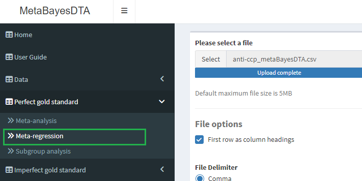

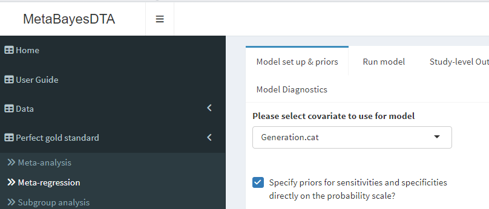

## 4.3 Compare the parameters

There are now three tables of parameter estimates: **Shared parameters**, **Group-specific parameters**, and **Pairwise accuracy differences and ratios**.

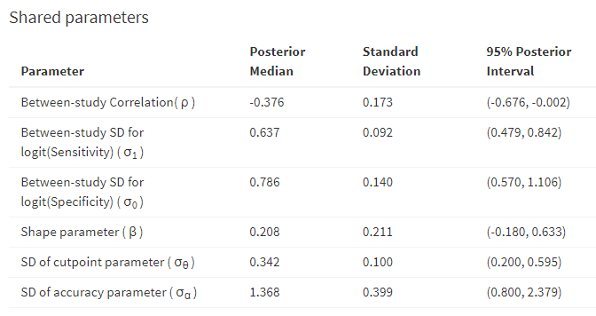

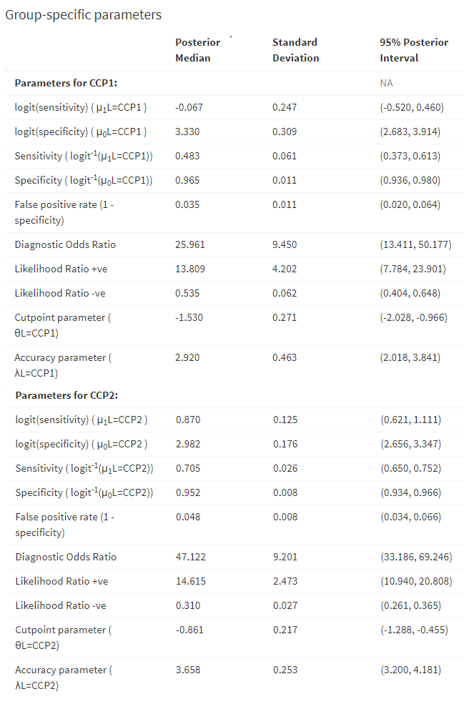

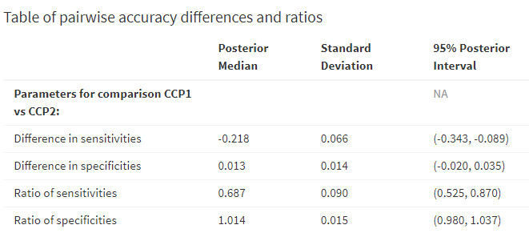

In the handbook, the parameter estimates from the frequentist model are on page 25 of chapter 9:

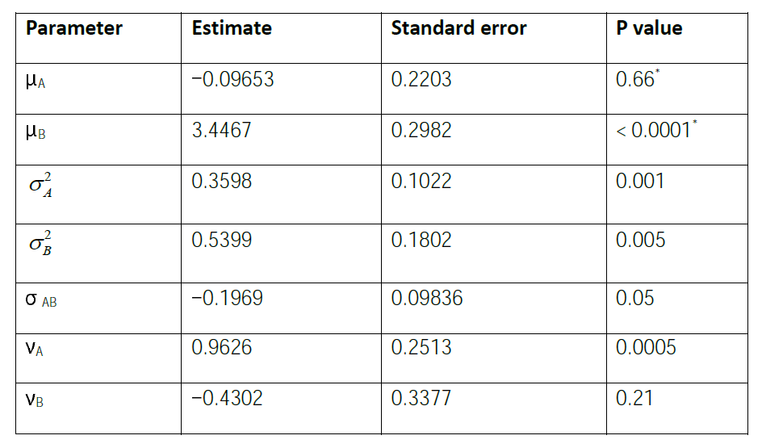

And from the Bayesian model on page 45 of chapter 10:

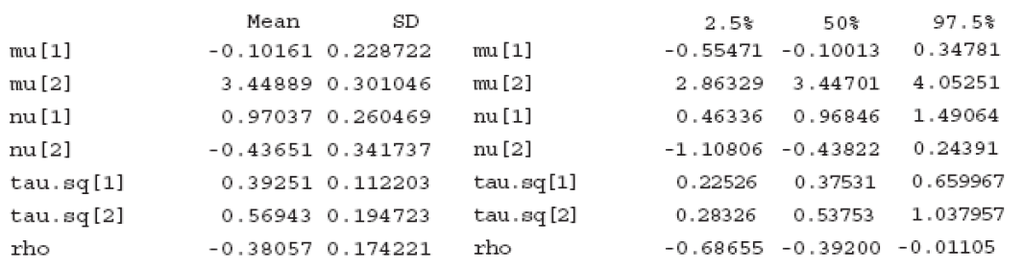

The three sources use different notation for the parameters. The table below shows which parameters are which.

| Parameters |  |  |  |  |  |  |  |
| --- | --- | --- | --- | --- | --- | --- | --- |
| Cochrane frequentist | $\mu_A$ | $\mu_B$ | $\sigma_A^2$ | $\sigma_B^2$ | $\sigma_{AB} / \sigma_A \sigma_B$ | $\nu_A$ | $\nu_B$ |
| Cochrane Bayesian | mu[1] | mu[2] | tau.sq[1] | tau.sq[2] | rho | nu[1] | nu[2] |
| MetaBayesDTA | $(\mu_1L=CCP1)$ | $(\mu_0L=CCP1)$ | $\sigma_1^2$ | $\sigma_0^2$ | $\rho$ | - | - |

### 4.3.1 Logit sensitivity parameters ($\mu_A$ and $\nu_A$)

| Parameter | Source | Estimate | Standard deviation | Lower 95% limit | Upper 95% limit |
| --- | --- | --- | --- | --- | --- |
| $\mu_A$ | Cochrane frequentist | -0.0965 | 0.2203 | NA | NA |
|  | Cochrane Bayesian | -0.1001 | 0.2287 | -0.5547 | 0.3478 |
|  | MetaBayesDTA | -0.0670 | 0.247 | -0.52 | 0.46 |
| $\nu_A$ | Cochrane frequentist | 0.9626 | 0.2513 | NA | NA |
|  | Cochrane Bayesian | 0.9685 | 0.2605 | 0.4634 | 1.4906 |
|  | MetaBayesDTA | 0.9370 | 0.2544 | 0.4384 | 1.4356 |

MetaBayesDTA provides the mean logit sensitivity for the two subgroups, which are $(\mu_1L=CCP1) = \mu_A$ in the CCP1 group and $(\mu_1L=CCP2) = \mu_A + \nu_A$ in the CCP2 group. The statistics for $\mu_A$ can be read from the output for $(\mu_1L=CCP1)$.

The parameter estimate for $\nu_A$ is $0.87 - -0.067 = 0.937$ where $0.87$ is $(\mu_1L=CCP2)$ and $-0.067$ is $(\mu_1L=CCP1)$.

The standard deviation of $\nu_A$ is

$$SD(\nu_A) = 0.637 \sqrt{37} / \sqrt{8 \times 29} = 0.2544$$

where 0.637 is $\sigma_A$ ($\sigma_1$ in MetaBayesDTA), 8 and 29 are the number of trials in the CCP1 and CCP2 groups respectively, and 37 is the total number of trials.

The 95% posterior interval for $\nu_A$ is then estimated by

$$0.937 \pm 1.96 \times 0.2544 = (0.4384, 1.4356)$$

# 5 Meta-regression in the HSROC model, 9.4.6.5 Example 2 continued: Investigating heterogeneity in diagnostic accuracy of rheumatoid factor (RF)

This is an extension of the model from section 3, using the same data set, *RF.csv*. As stated in that section, MetaBayesDTA obtains the parameters from the HSROC model by fitting the bivariate model and then converting the parameters. The procedure is valid because the two models are equivalent when there are no covariates. In this example, covariates are added to the cutpoint ($\theta$) and accuracy ($\alpha$) parameters, but not to the shape ($\beta$) parameter. This model is equivalent to the bivariate model with the addition of the same covariates to both the mean logit sensitivity and mean logit specificity. Therefore the procedure of fitting the bivariate model and deriving the parameter estimates for the HSROC model is also valid in this situation.

## 5.1 Format the dataset

Remember to rename the covariate **Method** to **Method.cat**.

Three of the trials are excluded from the example, so they must be deleted from the dataset. They are the ones that have **Method.cat** equal to “Not reported” or “RA hemagglutination”. Amongst the remaining forty seven, some have **Method.cat** equal to “Nephelometry” and some to “Nephelometry ”, with or without a space at the end. MetaBayesDTA will interpret these as different levels of the variable, so the spaces must be removed where they appear.

## 5.2 Analyse the data

Follow the instructions for meta-regression in section 4.

## 5.3 Add the SROC curve

In addition to ticking the **sROC curve** box, as in section 3, this time the **extrapolate HSROC curve beyond observed Se/Sp data points** should also be ticked.

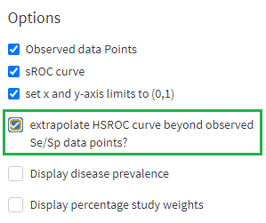

The SROC plot should look like this:

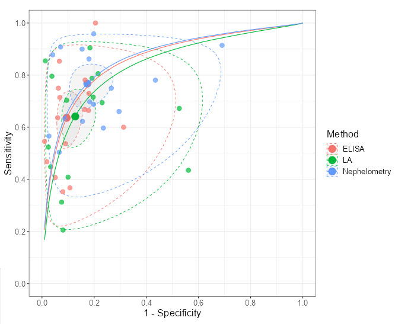